# Data Reanalysis Assignment Rmd [Curtis / Nov 10, 2016]

```r
knitr::opts_chunk$set(
    echo=TRUE,
    warning=FALSE,
    comment="##",
    prompt=FALSE,
    tidy=TRUE,
    tidy.opts=list(width.cutoff=75),
    fig.path="img/"
)
```

# Data Reanalysis Assignment

## Description of Original Paper

This is a data reanalysis of “The Influence of Maximum Running Speed on Eye Size: A Test of Leuckart’s Law in Mammals” (Heard-Booth & Kirk, 2012). The goal of this paper is to examine the relationship among axial eye diamater (measure of absolute eye size), and several related factors including maximum running speed, body mass, and activity pattern. Overall, the authors are looking for evidence of whether Leuckart’s Law (which states, “animals capable of achieving fast locomotor speeds require large eyes to enhance visual acuity and avoid collisions with environmental obstacles”) can be applied to mammals. The data for this study was pulled from various published sources and is presented in the form of species averages (n=50); the variables examined include axial eye diameter (mm), body mass (kg), maximum running speed (km/hr), in addition to a categorical variable of activity pattern. Relationships among the first three variables are analyzed using both ordinary least squares regressions and phylogenetic generalized least squares regressions. The Bininda-Emonds, 2008 phylogenetic tree is utilized for the latter. I will be replicating all regressions that were run in the paper. These include OLS and PGLS on each pair-wise comparison (e.g., AD~BM, AD~MRS, MRS~BM), as well as a multiple regression (wherein both MRS and BM are treated as predictor variables) and a partial phylogenetic regression of AD~MRS while holding BM constant. I have also replicated all plots published in the paper (published plots are included in this Rmd for comparison). Finally, for a descriptive analysis, I replicate the three Wilcoxon Rank-Sums tests in which differences in eye diameter and body mass are examined among activity patterns.

### Initial Steps: Loading R Packages

Let’s begin our journey! The first thing we need to do is load all the packages we will be using (Note: I’m using several packages that were not used by the authors because I’m a maverick that way, and I like these packages better.) Prior to calling these packages, obviously make sure they are installed. I didn’t include that step in my R chunk because it freaks out “The Knitter.”

[figure not shown]

```r
library(ape)
library(caper)
```

```r
library(ggplot2)
library(car)
library(coin)
```

### Initial Steps: Importing/Formatting Phylogenetic Tree and Dataset

In the below code I first read in the Nexus file for the phylogenetic tree that I will be using for the analysis (in this case: Bininda-Emonds, 2008). The initial object ‘trees3’ includes three separate versions of the tree (lower dates, best dates, and upper dates). I am only interested in using the ‘bestDates’ version, so I subset that tree out and assign it to the object ‘tree’

```r
trees3 <- read.nexus("C:/Users/EmmaKristina/Desktop/tree.txt")
head(trees3)
```

```
## 3 phylogenetic trees
```

```r
summary(trees3)
```

```
##                     Length Class Mode
## mammalST_bestDates  4      phylo list
## mammalST_lowerDates 4      phylo list
## mammalST_upperDates 4      phylo list
```

[figure not shown]

```r
tree <- trees3$mammalST_bestDates
plot(tree)  #This is clearly a giant clusterf**k but it at least shows that this object does in fact contain only one tree
```

Next I read in my dataset, which I have saved as a .csv file. I set stringsAsFactors equal to TRUE so that I can later run Wilcoxon Rank-Sum tests comparing activity patterns (classified as “d”, “n”, and “c” for diurnal, nocturnal, and cathemeral). All regressions in this paper are based on log10 transformed data. Rather than transforming the data within the regression equations, I create three new variables and bind them to my original dataset.

```r
data <- read.csv("C:/Users/EmmaKristina/Desktop/Heard-Booth&Kirk_2012_data.csv",
    header = TRUE, sep = ",", stringsAsFactors = TRUE)
head(data)
```

```
##          Order  Family         Genus.Species  BM   AD MRS ACT
## 1 Artiodactyla Bovidae    Aepyceros melampus  50 27.4  47   c
## 2 Artiodactyla Bovidae Alcelaphus buselaphus 170 32.8  80   c
## 3 Artiodactyla Bovidae   Antilope cervicapra  37 28.0 105   c
## 4 Artiodactyla Bovidae           Bison bison 865 36.8  56   c
## 5 Artiodactyla Bovidae     Connochaetes gnou 300 26.5  90   c
## 6 Artiodactyla Bovidae   Hippotragus equinus 250 21.6  56   c
```

```r
logBM <- log10(data$BM)
logAD <- log10(data$AD)
logMRS <- log10(data$MRS)
data <- data.frame(cbind(data, logBM, logAD, logMRS))
names(data) <- c("Order", "Family", "Genus.species", "BM", "AD", "MRS", "ACT",
    "logBM", "logAD", "logMRS")
data$Genus.species <- gsub(" ", "_", data$Genus.species)  # Matching the format of species' names in the data table to that in the Nexus file. This step will be necessary for running pgls in caper
head(data)
```

```
##          Order  Family         Genus.species  BM   AD MRS ACT    logBM
## 1 Artiodactyla Bovidae    Aepyceros_melampus  50 27.4  47   c 1.698970
## 2 Artiodactyla Bovidae Alcelaphus_buselaphus 170 32.8  80   c 2.230449
## 3 Artiodactyla Bovidae   Antilope_cervicapra  37 28.0 105   c 1.568202
## 4 Artiodactyla Bovidae           Bison_bison 865 36.8  56   c 2.937016
## 5 Artiodactyla Bovidae     Connochaetes_gnou 300 26.5  90   c 2.477121
## 6 Artiodactyla Bovidae   Hippotragus_equinus 250 21.6  56   c 2.397940
##      logAD   logMRS
## 1 1.437751 1.672098
## 2 1.515874 1.903090
## 3 1.447158 2.021189
## 4 1.565848 1.748188
## 5 1.423246 1.954243
## 6 1.334454 1.748188
```

The next chunk is not actually necessary for running pgls in caper as that package automatically trims you phylo tree to include only the species in your dataset. That being said, I’d already done this pruning shindig before I realized that so I’m leaving it in. It also allows for nice visualization of the tree for the subset of mammals this paper is analysing.

```r
species <- c("Aepyceros_melampus", "Alcelaphus_buselaphus", "Antilope_cervicapra",
    "Bison_bison", "Connochaetes_gnou", "Hippotragus_equinus", "Taurotragus_oryx",
    "Alces_alces", "Cervus_elaphus", "Dama_dama", "Odocoileus_hemionus", "Odocoileus_virginianus",
    "Giraffa_camelopardalis", "Canis_lupus", "Urocyon_cinereoargenteus", "Vulpes_vulpes",
    "Acinonyx_jubatus", "Panthera_leo", "Panthera_tigris", "Crocuta_crocuta",
    "Meles_meles", "Procyon_lotor", "Ursus_americanus", "Ursus_arctos", "Dasyurus_viverrinus",
    "Didelphis_marsupialis", "Didelphis_virginiana", "Bettongia_penicillata",
    "Lepus_californicus", "Sylvilagus_audubonii", "Diceros_bicornis", "Equus_burchellii",
    "Equus_caballus", "Equus_zebra", "Cebus_capucinus", "Erythrocebus_patas",
    "Gorilla_gorilla", "Elephas_maximus", "Loxodonta_africana", "Microtus_pennsylvanicus",
    "Peromyscus_maniculatus", "Zapus_hudsonius", "Erethizon_dorsatum", "Myoxus_glis",
    "Rattus_rattus", "Marmota_monax", "Sciurus_carolinensis", "Sciurus_niger",
    "Tamias_striatus", "Tamiasciurus_hudsonicus")
str(species)
```

```
##  chr [1:50] "Aepyceros_melampus" "Alcelaphus_buselaphus" ...
```

```r
pruned.tree <- drop.tip(tree, setdiff(tree$tip.label, species))
write.tree(pruned.tree)
```

[output not shown]

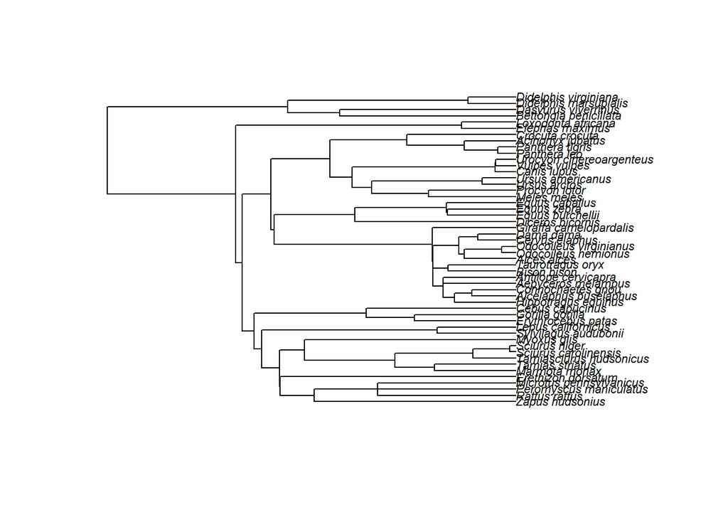

```r
plot(pruned.tree, cex = 0.7)
```

### Ordinary Least Squares and Phylogenetic Least Squares Regressions

The following regression statistics are looking at the linear relationships among the three (log-transformed–from here on out just assume that’s implied) variables: body mass (‘logBM’), axial eye diameter (‘logAD’), and maximum running speed (‘logMRS’). They are analysed first in a pair-wise fashion first using ordinary least squares regressions, then using phylogenetic generalized least squares regressions in order to examine the effect of phylogenetic inertia (i.e., similarity due to shared ancestry) on the observed relationships. PGLS does this by essentially adding an error term to the least squares regression which corrects for phylogenetic non-independence. Specifically, we are setting the parameters of the PGLS regression to use a maximum likelihood approach to estimate Pagel’s lambda. [Note: my PGLS results differ a bit from those in the paper, particularly in the magnitude of the AIC values. This is likely due to the fact that I am running my PGLS regressions using *caper* rather than *ape*. However, the relationships among the AIC values-in terms of which is lowest, highest, etc-still matches the results of the paper.]

In addition to these pair-wise regressions, the authors also run a multiple regression to examine the combined effect of body mass and maximum running speed on axial eye diameter. Finally, they run a partial phylogenetic regression on the residuals of the PGLS models for axial diameter on body mass and maximum running speed on body mass. This provides a means for examining the effect of running speed on eye diameter when body mass is held constant.

Below is the table of results provided in the paper for comparison:

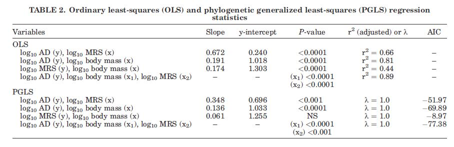

```r
myobject <- comparative.data(phy = tree, data = data, names.col = Genus.species,
    vcv = TRUE, na.omit = FALSE, warn.dropped = TRUE)  #This creates the object that 'caper' will use to run the PGLS

summary(myobject$dropped)  #checking to make sure none of my rows of data were dropped
```

```
##                Length Class  Mode
## tips           4460   -none- character
## unmatched.rows    0   -none- character
```

```r
str(myobject)  #Checking out the object's structure just for shits and giggles
```

```
## List of 7
##  $ phy      :List of 5
##   ..$ edge       : int [1:96, 1:2] 51 52 53 54 55 56 57 58 58 59 ...
##   ..$ Nnode      : int 47
##   ..$ tip.label  : chr [1:50] "Zapus_hudsonius" "Rattus_rattus" "Peromyscus_maniculatus" "Microtus_pennsylvanicus" ...
##   ..$ edge.length: num [1:96] 46.4 2.4 4.4 2.7 6.5 0.2 12.3 72.8 22.9 49.9 ...
##   ..$ node.label : int [1:47] 51 52 53 54 55 56 57 58 59 60 ...
##   ..- attr(*, "class")= chr "phylo"
##   ..- attr(*, "order")= chr "cladewise"
##  $ data     :'data.frame':   50 obs. of  9 variables:
##   ..$ Order : Factor w/ 10 levels "Artiodactyla",..: 10 10 10 10 10 10 10 10 10 10 ...
##   ..$ Family: Factor w/ 24 levels "Bovidae","Canidae",..: 9 19 6 6 12 23 23 23 23 23 ...
##   ..$ BM    : num [1:50] 0.018 0.25 0.03 0.05 9 4 0.1 0.22 0.55 1.1 ...
##   ..$ AD    : num [1:50] 3.4 6.3 4.9 3.4 10.3 12.1 7.1 8.7 11.8 12 ...
##   ..$ MRS   : num [1:50] 8.9 9.7 9.1 11 3.2 16 17 15 27 24 ...
##   ..$ ACT   : Factor w/ 3 levels "c","d","n": 1 3 3 1 1 2 2 2 2 2 ...
##   ..$ logBM : num [1:50] -1.745 -0.602 -1.523 -1.301 0.954 ...
##   ..$ logAD : num [1:50] 0.531 0.799 0.69 0.531 1.013 ...
##   ..$ logMRS: num [1:50] 0.949 0.987 0.959 1.041 0.505 ...
##  $ data.name: chr "data"
##  $ phy.name : chr "tree"
##  $ dropped  :List of 2
##   ..$ tips          : chr [1:4460] "Tachyglossus_aculeatus" "Zaglossus_bruijni" "Ornithorhynchus_anatinus" "Anomalurus_beecrofti" ...
##   ..$ unmatched.rows: chr(0)
##  $ vcv      : VCV.array [1:50, 1:50] 147.7 74.9 74.9 74.9 62.6 ...
##   ..- attr(*, "dimnames")=List of 2
##   .. ..$ : chr [1:50] "Zapus_hudsonius" "Rattus_rattus" "Peromyscus_maniculatus" "Microtus_pennsylvanicus" ...
##   .. ..$ : chr [1:50] "Zapus_hudsonius" "Rattus_rattus" "Peromyscus_maniculatus" "Microtus_pennsylvanicus" ...
##  $ vcv.dim  : num 2
##  - attr(*, "class")= chr "comparative.data"
```

#### Log10 Axial Eye Diameter ~ Log10 Max Running Speed

```r
olsModel1 <- lm(logAD ~ logMRS, data = data)
summary(olsModel1)
```

```
##
## Call:
## lm(formula = logAD ~ logMRS, data = data)
##
## Residuals:
##      Min       1Q   Median       3Q      Max
## -0.40804 -0.10313 -0.02262  0.12633  0.43342
##
## Coefficients:
##             Estimate Std. Error t value Pr(>|t|)
## (Intercept)  0.24019    0.10754   2.233   0.0302 *
## logMRS       0.67154    0.06846   9.809 4.74e-13 ***
## ---
## Signif. codes:  0 '***' 0.001 '**' 0.01 '*' 0.05 '.' 0.1 ' ' 1
##
## Residual standard error: 0.1731 on 48 degrees of freedom
## Multiple R-squared:  0.6672, Adjusted R-squared:  0.6602
## F-statistic: 96.22 on 1 and 48 DF,  p-value: 4.74e-13
```

```r
model.pgls1 <- pgls(log10(AD) ~ log10(MRS), data = myobject, lambda = "ML")
summary(model.pgls1)
```

```
##
## Call:
## pgls(formula = log10(AD) ~ log10(MRS), data = myobject, lambda = "ML")
##
## Residuals:
##      Min       1Q   Median       3Q      Max
## -0.02938 -0.01099  0.00235  0.01419  0.04530
##
## Branch length transformations:
##
## kappa  [Fix]  : 1.000
## lambda [ ML]  : 1.000
##    lower bound : 0.000, p = 8.4624e-08
##    upper bound : 1.000, p = 1
##    95.0% CI   : (0.946, NA)
## delta  [Fix]  : 1.000
##
## Coefficients:
##             Estimate Std. Error t value  Pr(>|t|)
## (Intercept) 0.654905   0.165860  3.9485 0.0002564 ***
## log10(MRS)  0.380530   0.092625  4.1083 0.0001545 ***
## ---
## Signif. codes:  0 '***' 0.001 '**' 0.01 '*' 0.05 '.' 0.1 ' ' 1
##
## Residual standard error: 0.01872 on 48 degrees of freedom
## Multiple R-squared: 0.2601,  Adjusted R-squared: 0.2447
## F-statistic: 16.88 on 1 and 48 DF,  p-value: 0.0001545
```

```r
model.pgls1$aic
```

```
##           [,1]
## [1,] -60.24978
```

Below we can compare the published plot of the models with my plot: (Look pretty similar!)

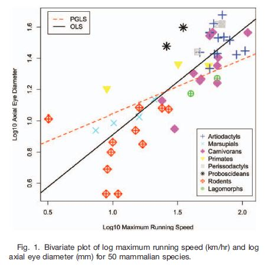

```r
## Plot of logAD ~ logMRS

as.factor(data$order)
```

```
## factor(0)
## Levels:
```

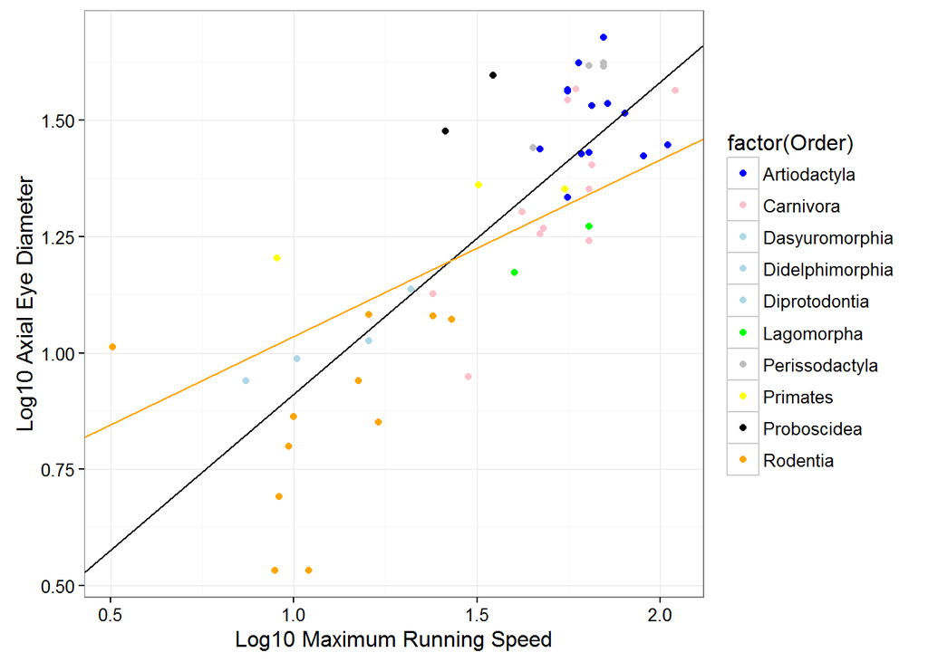

```r
p1 <- ggplot(data = data, aes(x = logMRS, y = logAD)) + geom_point(aes(color = factor(Order))) +
    scale_color_manual(values = c("blue", "pink", "lightblue", "lightblue",
        "lightblue", "green", "gray", "yellow", "black", "orange")) + geom_abline(slope = olsModel1$coefficients[2],
    intercept = olsModel1$coefficients[1], color = "black") + xlab("Log10 Maximum Running Speed") +
    ylab("Log10 Axial Eye Diameter") + geom_abline(slope = model.pgls1$model$coef[2],
    intercept = model.pgls1$model$coef[1], color = "orange") + theme_bw()
p1
```

#### Log10 Axial Eye Diameter ~ Log10 Body Mass

```r
olsModel2 <- lm(logAD ~ logBM, data = data)
summary(olsModel2)
```

```
##
## Call:
## lm(formula = logAD ~ logBM, data = data)
##
## Residuals:
##      Min       1Q   Median       3Q      Max
## -0.26772 -0.10163  0.03444  0.10170  0.21372
##
## Coefficients:
##             Estimate Std. Error t value Pr(>|t|)
## (Intercept)  1.01771    0.02516   40.45   <2e-16 ***
## logBM        0.19147    0.01323   14.47   <2e-16 ***
## ---
## Signif. codes:  0 '***' 0.001 '**' 0.01 '*' 0.05 '.' 0.1 ' ' 1
##
## Residual standard error: 0.1295 on 48 degrees of freedom
## Multiple R-squared:  0.8136, Adjusted R-squared:  0.8097
## F-statistic: 209.5 on 1 and 48 DF,  p-value: < 2.2e-16
```

```r
model.pgls2 <- pgls(log10(AD) ~ log10(BM), data = myobject, lambda = "ML")
summary(model.pgls2)
```

```
##
## Call:
## pgls(formula = log10(AD) ~ log10(BM), data = myobject, lambda = "ML")
##
## Residuals:
##       Min        1Q    Median        3Q       Max
## -0.035912 -0.012628  0.000295  0.008062  0.036525
##
## Branch length transformations:
##
## kappa  [Fix]  : 1.000
## lambda [ ML]  : 1.000
##    lower bound : 0.000, p = 2.2131e-06
##    upper bound : 1.000, p = 1
##    95.0% CI   : (0.903, NA)
## delta  [Fix]  : 1.000
##
## Coefficients:
##             Estimate Std. Error t value  Pr(>|t|)
## (Intercept) 1.032026   0.091291 11.3048 3.997e-15 ***
## log10(BM)   0.139550   0.018968  7.3571 2.089e-09 ***
## ---
## Signif. codes:  0 '***' 0.001 '**' 0.01 '*' 0.05 '.' 0.1 ' ' 1
##
## Residual standard error: 0.01492 on 48 degrees of freedom
## Multiple R-squared:  0.53,   Adjusted R-squared: 0.5202
## F-statistic: 54.13 on 1 and 48 DF,  p-value: 2.089e-09
```

```r
model.pgls2$aic
```

```
##           [,1]
## [1,] -82.93539
```

Compare the plots:

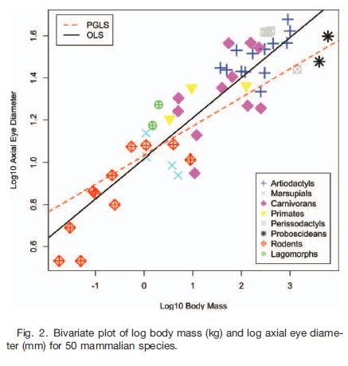

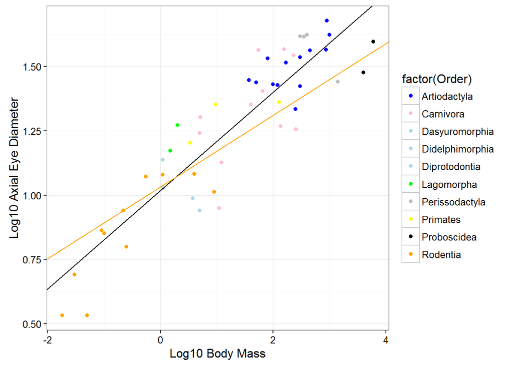

```r
## Plot of logAD ~ logBM

p2 <- ggplot(data = data, aes(x = logBM, y = logAD)) + geom_point(aes(color = factor(Order))) +
    scale_color_manual(values = c("blue", "pink", "lightblue", "lightblue",
        "lightblue", "green", "gray", "yellow", "black", "orange")) + geom_abline(slope = olsModel2$coefficients[2],
    intercept = olsModel2$coefficients[1], color = "black") + xlab("Log10 Body Mass") +
    ylab("Log10 Axial Eye Diameter") + geom_abline(slope = model.pgls2$model$coef[2],
    intercept = model.pgls2$model$coef[1], color = "orange") + theme_bw()
p2
```

#### Log10 Maximum Running Speed ~ Log10 Body Mass

```r
# Log10 Max Running Speed ~ Log10 Body Mass

olsModel3 <- lm(logMRS ~ logBM, data = data)
summary(olsModel3)
```

```
##
## Call:
## lm(formula = logMRS ~ logBM, data = data)
##
## Residuals:
##      Min       1Q   Median       3Q      Max
## -0.96380 -0.10089  0.02894  0.16871  0.45056
##
## Coefficients:
##             Estimate Std. Error t value Pr(>|t|)
## (Intercept)   1.3034     0.0525  24.828  < 2e-16 ***
## logBM         0.1735     0.0276   6.286 9.14e-08 ***
## ---
## Signif. codes:  0 '***' 0.001 '**' 0.01 '*' 0.05 '.' 0.1 ' ' 1
##
## Residual standard error: 0.2702 on 48 degrees of freedom
## Multiple R-squared:  0.4516, Adjusted R-squared:  0.4401
## F-statistic: 39.52 on 1 and 48 DF,  p-value: 9.139e-08
```

```r
model.pgls3 <- pgls(logMRS ~ logBM, data = myobject, lambda = "ML")
summary(model.pgls3)
```

```
##
## Call:
## pgls(formula = logMRS ~ logBM, data = myobject, lambda = "ML")
##
## Residuals:
##       Min        1Q    Median        3Q       Max
## -0.066898 -0.019733  0.000203  0.014802  0.058372
##
## Branch length transformations:
##
## kappa  [Fix]  : 1.000
## lambda [ ML]  : 1.000
##    lower bound : 0.000, p = 1.4028e-08
##    upper bound : 1.000, p = 1
##    95.0% CI   : (0.930, NA)
## delta  [Fix]  : 1.000
##
## Coefficients:
##             Estimate Std. Error t value  Pr(>|t|)
## (Intercept) 1.257613   0.172711  7.2816 2.725e-09 ***
## logBM       0.064812   0.035885  1.8061   0.07718 .
## ---
## Signif. codes:  0 '***' 0.001 '**' 0.01 '*' 0.05 '.' 0.1 ' ' 1
##
## Residual standard error: 0.02823 on 48 degrees of freedom
## Multiple R-squared: 0.06363, Adjusted R-squared: 0.04413
## F-statistic: 3.262 on 1 and 48 DF,  p-value: 0.07718
```

```r
model.pgls3$aic
```

```
##           [,1]
## [1,] -19.17808
```

Pretty plots looking the same!:

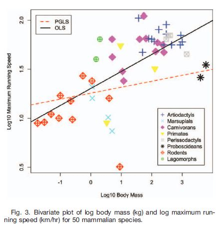

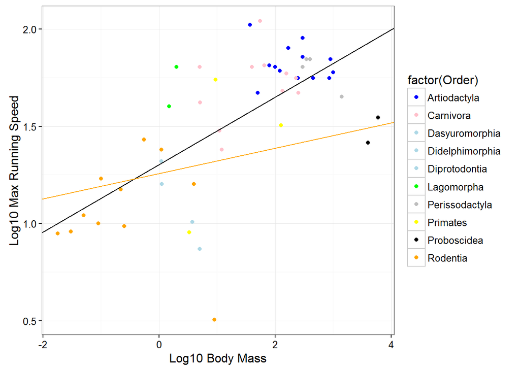

```r
## Plot of logMRS ~ logBM

p3 <- ggplot(data = data, aes(x = logBM, y = logMRS)) + geom_point(aes(color = factor(Order))) +
    scale_color_manual(values = c("blue", "pink", "lightblue", "lightblue",
        "lightblue", "green", "gray", "yellow", "black", "orange")) + geom_abline(slope = olsModel3$coefficients[2],
    intercept = olsModel3$coefficients[1], color = "black") + xlab("Log10 Body Mass") +
    ylab("Log10 Max Running Speed") + geom_abline(slope = model.pgls3$model$coef[2],
    intercept = model.pgls3$model$coef[1], color = "orange") + theme_bw()
p3
```

#### Multiple Regression: Log10 Axial Eye Diameter ~ Log10 Body Mass + Log10 Max Running Speed

```r
olsModel4 <- lm(logAD ~ logBM * logMRS, data = data)  #Also testing for effect of interaction b/w BM and MRS
summary(olsModel4)
```

```
##
## Call:
## lm(formula = logAD ~ logBM * logMRS, data = data)
##
## Residuals:
##      Min       1Q   Median       3Q      Max
## -0.28038 -0.03993  0.01647  0.06598  0.21889
##
## Coefficients:
##              Estimate Std. Error t value Pr(>|t|)
## (Intercept)   0.56394    0.08341   6.761 2.08e-08 ***
## logBM         0.19414    0.06081   3.192  0.00254 **
## logMRS        0.35623    0.06712   5.308 3.11e-06 ***
## logBM:logMRS -0.04065    0.04193  -0.970  0.33735
## ---
## Signif. codes:  0 '***' 0.001 '**' 0.01 '*' 0.05 '.' 0.1 ' ' 1
##
## Residual standard error: 0.09852 on 46 degrees of freedom
## Multiple R-squared:  0.8966, Adjusted R-squared:  0.8899
## F-statistic:   133 on 3 and 46 DF,  p-value: < 2.2e-16
```

```r
anovaModel4 <- car::Anova(olsModel4, type = 2)  #Since the interaction was not significant, I am using a Type II ANOVA. From this I will extract the sum of squares values in order to calculate the partial R-quared values
print(anovaModel4)
```

```
## Anova Table (Type II tests)
##
## Response: logAD
##               Sum Sq Df F value    Pr(>F)
## logBM        0.98214  1 101.181 3.376e-13 ***
## logMRS       0.34966  1  36.022 2.877e-07 ***
## logBM:logMRS 0.00912  1   0.940    0.3373
## Residuals    0.44651 46
## ---
## Signif. codes:  0 '***' 0.001 '**' 0.01 '*' 0.05 '.' 0.1 ' ' 1
```

```r
BM_partialR2 <- anovaModel4[1, 1]/sum(anovaModel4$`Sum Sq`)
BM_partialR2
```

```
## [1] 0.5494696
```

```r
MRS_partialR2 <- anovaModel4[2, 1]/sum(anovaModel4$`Sum Sq`)
MRS_partialR2
```

```
## [1] 0.1956198
```

```r
# These partial R squared values do not match those in the paper. Not sure
# why this is, but they also don't specify the way in which they generated
# their partial R^2 values.

model.pgls4 <- pgls(logAD ~ logBM * logMRS, data = myobject, lambda = "ML")
summary(model.pgls4)
```

```
##
## Call:
## pgls(formula = logAD ~ logBM * logMRS, data = myobject, lambda = "ML")
##
## Residuals:
##        Min         1Q     Median         3Q        Max
## -0.0261713 -0.0093847 -0.0007155  0.0072068  0.0251191
##
## Branch length transformations:
##
## kappa  [Fix]  : 1.000
## lambda [ ML]  : 1.000
##    lower bound : 0.000, p = 0.003607
##    upper bound : 1.000, p = 1
##    95.0% CI   : (0.676, NA)
## delta  [Fix]  : 1.000
##
## Coefficients:
##               Estimate Std. Error t value  Pr(>|t|)
## (Intercept)   0.638822   0.127117  5.0254  8.07e-06 ***
## logBM         0.214921   0.075114  2.8613 0.0063284 **
## logMRS        0.317269   0.080666  3.9331 0.0002807 ***
## logBM:logMRS -0.063387   0.050264 -1.2611 0.2136370
## ---
## Signif. codes:  0 '***' 0.001 '**' 0.01 '*' 0.05 '.' 0.1 ' ' 1
##
## Residual standard error: 0.01304 on 46 degrees of freedom
## Multiple R-squared: 0.6557,  Adjusted R-squared: 0.6332
## F-statistic:  29.2 on 3 and 46 DF,  p-value: 1.008e-10
```

```r
model.pgls4$aic
```

```
##           [,1]
## [1,] -94.49372
```

#### Partial PGLS Regression: Residual Log10 Axial Eye Diameter ~ Residual Log10 Max Running Speed

```r
model.pgls5 <- pgls(resid(model.pgls2) ~ resid(model.pgls3) + 0, data = myobject,
    lambda = "ML")  #Trying to match the paper as closely as possible, I set the intercept equal to zero
summary(model.pgls5)
```

```
##
## Call:
## pgls(formula = resid(model.pgls2) ~ resid(model.pgls3) + 0, data = myobject,
##     lambda = "ML")
##
## Residuals:
##       Min        1Q    Median        3Q       Max
## -0.025161 -0.008059 -0.000650  0.009730  0.022625
##
## Branch length transformations:
##
## kappa  [Fix]  : 1.000
## lambda [ ML]  : 0.985
##    lower bound : 0.000, p = 0.00094334
##    upper bound : 1.000, p = 0.76526
##    95.0% CI   : (0.732, NA)
## delta  [Fix]  : 1.000
##
## Coefficients:
##                    Estimate Std. Error t value Pr(>|t|)
## resid(model.pgls3) 0.265065   0.065221  4.0641 0.000174 ***
## ---
## Signif. codes:  0 '***' 0.001 '**' 0.01 '*' 0.05 '.' 0.1 ' ' 1
##
## Residual standard error: 0.01239 on 49 degrees of freedom
## Multiple R-squared: 0.2521,  Adjusted R-squared: 0.2521
## F-statistic:   Inf on 0 and 49 DF,  p-value: NA
```

```r
model.pgls5$aic
```

```
##           [,1]
## [1,] -98.88346
```

```r
model.pgls5$model$coef
```

```
##                         [,1]
## resid(model.pgls3) 0.2650649
## attr(,"names")
## [1] "resid(model.pgls3)"
```

```r
pglsorders <- read.csv("C:/Users/EmmaKristina/Desktop/pglsorders.csv", header = T,
    sep = ",", stringsAsFactors = T)
resid_df <- cbind.data.frame(pglsorders, resid(model.pgls2), resid(model.pgls3))
colnames(resid_df) <- c("Order", "ADresid", "MRSresid")
```

Once again we can compare the plots, which look pretty similar despite the discrepancy between my slope value and the published value (0.259).

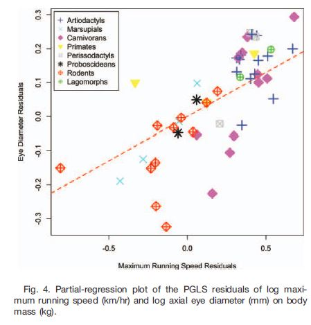

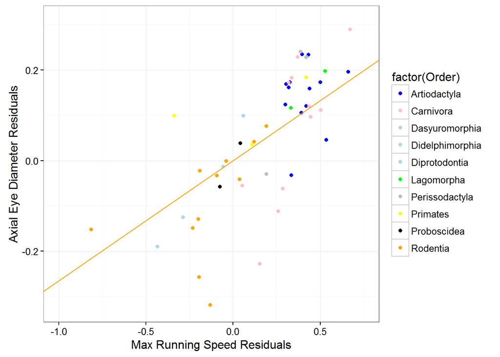

```r
# Plot of AD residuals~MRS residuals
p5 <- ggplot(data = resid_df, aes(x = MRSresid, y = ADresid)) + geom_point(aes(color = factor(Order))) +
    xlab("Max Running Speed Residuals") + ylab("Axial Eye Diameter Residuals") +
    geom_abline(slope = model.pgls5$model$coef[1], intercept = 0, color = "orange") +
    xlim(c(-1, 0.75)) + ylim(c(-0.325, 0.31)) + scale_color_manual(values = c("blue",
    "pink", "lightblue", "lightblue", "lightblue", "green", "gray", "yellow",
    "black", "orange")) + theme_bw()
p5
```

### Wilcoxon Rank-Sums Tests

The following utilizes Wilcoxon Rank-Sums to examine the variation in eye diameter and body mass among the three activity pattern groups: diurnal, nocturnal, and cathemeral.

```r
# Diurnal vs. Nocturnal-->Not statistically significant difference
actd <- data$ACT == "d"
diurnal <- data[actd, ]
actn <- data$ACT == "n"
nocturnal <- data[actn, ]
DvN <- rbind(diurnal, nocturnal)
coin::wilcox_test(AD ~ ACT, data = DvN, distribution = "exact")
```

```
##
##  Exact Wilcoxon-Mann-Whitney Test
##
## data:  AD by ACT (d, n)
## Z = 1.1028, p-value = 0.287
## alternative hypothesis: true mu is not equal to 0
```

```r
# Cathemeral vs. Combined Diurnal and Nocturnal--> Statistically significant
# differences
DvN$ACT[DvN$ACT == "n"] <- "d"
actc <- data$ACT == "c"
cathemeral <- data[actc, ]
DNvC <- rbind(DvN, cathemeral)
coin::wilcox_test(AD ~ ACT, data = DNvC, distribution = "exact")  #Published results:(p<0.001, Z=-3.65)
```

```
##
##  Exact Wilcoxon-Mann-Whitney Test
##
## data:  AD by ACT (c, d)
## Z = 3.658, p-value = 0.0001433
## alternative hypothesis: true mu is not equal to 0
```

```r
coin::wilcox_test(BM ~ ACT, data = DNvC, distribution = "exact")  #Published results:(p<0.001, Z=-3.87)
```

```
##
##  Exact Wilcoxon-Mann-Whitney Test
##
## data:  BM by ACT (c, d)
## Z = 3.8381, p-value = 5.941e-05
## alternative hypothesis: true mu is not equal to 0
```